# Practical Machine Learning Assignment

George Kyritsis

Tuesday, September 16, 2014

Using devices such as Jawbone Up, Nike FuelBand, and Fitbit it is now possible to collect a large amount of data about personal activity relatively inexpensively. These type of devices are part of the quantified self movement – a group of enthusiasts who take measurements about themselves regularly to improve their health, to find patterns in their behavior, or because they are tech geeks. One thing that people regularly do is quantify how much of a particular activity they do, but they rarely quantify how well they do it.

In this project, i will be to use data from accelerometers on the belt, forearm, arm, and dumbell of 6 participants. They were asked to perform barbell lifts correctly and incorrectly in 5 different ways. More information is available from the website here: http://groupware.les.inf.puc-rio.br/har.The goal is to predict the manner in which they did the exercise.

## Setting the Working Directory

```r
setwd("C:/Users/George/Coursera/Machine_Learning_Project")
```

## Downloading the Data

```r
#Downloading the training set
download.file("https://d396qusza40orc.cloudfront.net/predmachlearn/pml-training.csv", destfile = "pml-training.csv")

#Downloading the test set
download.file("http://d396qusza40orc.cloudfront.net/predmachlearn/pml-testing.csv", destfile = "pml-testing.csv")
```

## Loading the Data

```r
trainingOriginal = read.csv("pml-training.csv", header = TRUE, na.strings = c("", "NA"))
dim(trainingOriginal)
```

```
## [1] 19622   160
```

```r
testingOriginal = read.csv("pml-testing.csv", na.strings = c("", "NA"))
dim(testingOriginal)
```

```
## [1]  20 160
```

## Reducing the number of predictors

Removing the Columns with NAs

```r
trainingRemovedNA = trainingOriginal[, colSums(is.na(trainingOriginal)) == 0]
dim(trainingRemovedNA)
```

```
## [1] 19622    60
```

Removing more Columns that are irrelevant. Those are X, the username, the variables measuring time and new_window and num_window (the first 7 columns)

```r
trainingIrrelevant = trainingRemovedNA[, -c(1:7)]
dim(trainingIrrelevant)
```

```
## [1] 19622    53
```

Finding the variables with high correlation and constructing a correlation Matrix

```r
M = abs(cor(trainingIrrelevant[, -53]))
diag(M) = 0
which(M > 0.90, arr.ind = T)
```

```
##                  row col
## total_accel_belt   4   1
## accel_belt_y       9   1
## accel_belt_z      10   1
## accel_belt_x       8   2
## roll_belt          1   4
## accel_belt_y       9   4
## accel_belt_z      10   4
## pitch_belt         2   8
## roll_belt          1   9
## total_accel_belt   4   9
## accel_belt_z      10   9
## roll_belt          1  10
## total_accel_belt   4  10
## accel_belt_y       9  10
## gyros_arm_y       19  18
## gyros_arm_x       18  19
## gyros_dumbbell_z  33  31
## gyros_forearm_z   46  31
## gyros_dumbbell_x  31  33
## gyros_forearm_z   46  33
## gyros_dumbbell_x  31  46
## gyros_dumbbell_z  33  46
```

A graphical Display of the Correlation Matrix

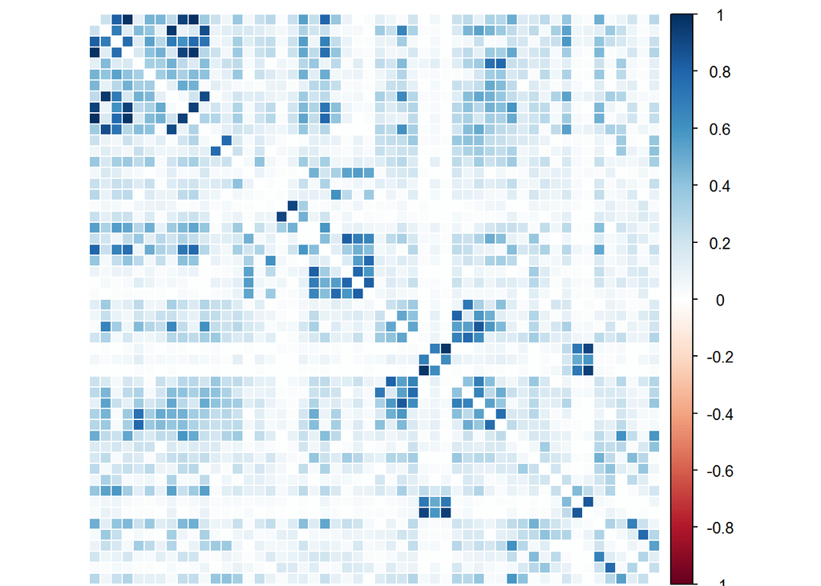

```r
library(corrplot)
corrplot(M, method = "color", tl.pos = "n")
```

Searching through a correlation matrix and removing columns from the training set to reduce pair-wise correlations

```r
library(caret)
removeCorColumns = findCorrelation(M, cutoff = .90, verbose = FALSE)
trainingCor = trainingIrrelevant[, -c(removeCorColumns)]
dim(trainingCor)
```

```
## [1] 19622    46
```

## Splitting the data to training and test sets for cross validation

```r
inTrain = createDataPartition(y = trainingCor$classe, p = 0.7, list = FALSE)
training = trainingCor[inTrain, ]
testing = trainingCor[-inTrain, ]
```

## Random Forests

```r
set.seed(21)
```

Fitting the model

```r
library(randomForest)
modFit = randomForest(classe ~., data=training,  importance=TRUE)
modFit
```

```
##
## Call:
##  randomForest(formula = classe ~ ., data = training, importance = TRUE)
##                Type of random forest: classification
##                      Number of trees: 500
## No. of variables tried at each split: 6
##
##         OOB estimate of  error rate: 0.51%
## Confusion matrix:
##      A    B    C    D    E class.error
## A 3904    1    0    1    0    0.000512
## B   16 2634    8    0    0    0.009029
## C    0   14 2380    1    1    0.006678
## D    0    0   22 2228    2    0.010657
## E    0    0    1    3 2521    0.001584
```

Plotting the overall error of the model

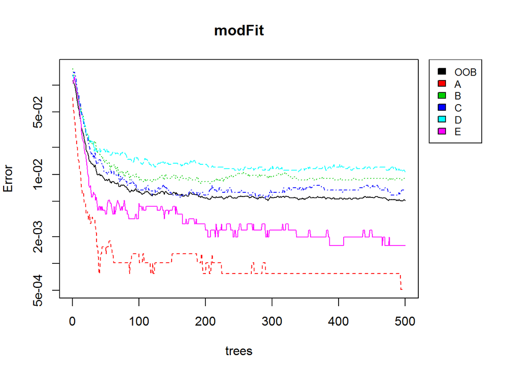

```r
layout(matrix(c(1,2),nrow=1),
       width=c(4,1))
par(mar=c(5,4,4,0)) #No margin on the right side
plot(modFit, log="y")
par(mar=c(5,0,4,2)) #No margin on the left side
plot(c(0,1),type="n", axes=F, xlab="", ylab="")
legend("top", colnames(modFit$err.rate),col=1:6,cex=0.8,fill=1:6)
```

Plotting the variable importance

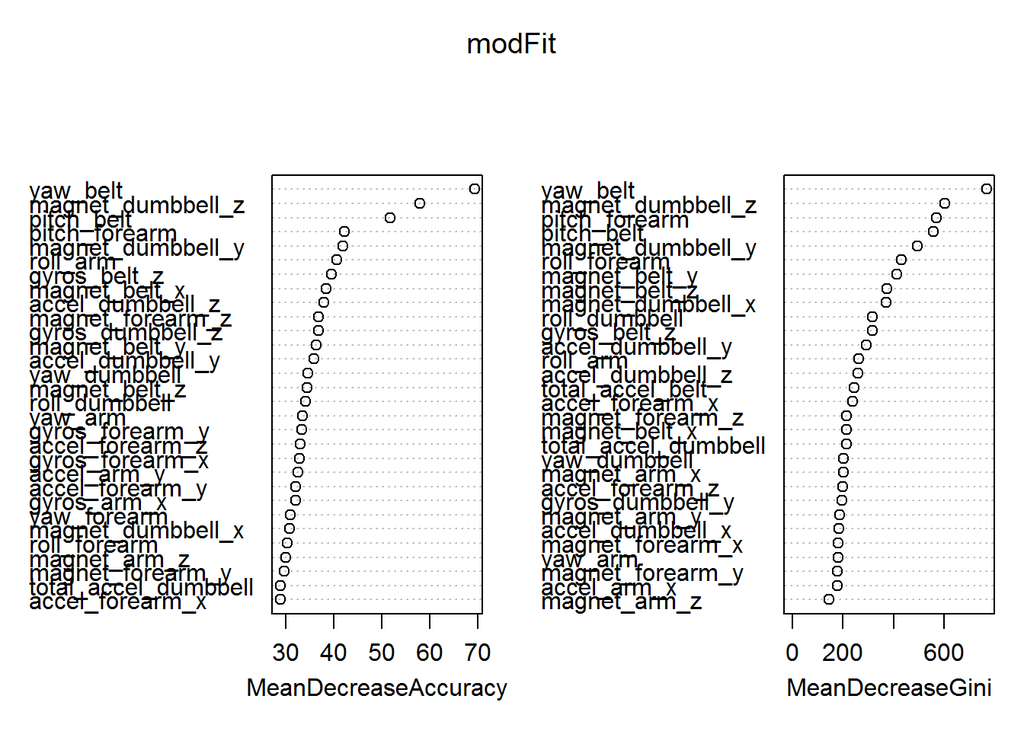

```r
varImpPlot(modFit)
```

Predicting new values

```r
pred = predict(modFit, testing)
testing$predRight = pred == testing$classe
predM = table(pred, testing$classe)
predM
```

```
##
## pred    A    B    C    D    E
##    A 1673    5    0    0    0
##    B    0 1133    8    0    0
##    C    0    1 1017    7    2
##    D    0    0    1  956    0
##    E    1    0    0    1 1080
```

Out of sample Accuracy

```r
sum(diag(predM))/sum(sum(predM))
```

```
## [1] 0.9956
```

The Estimate is very Accurate

## Predicting the manner in which they did the exercise (A, B, C, D or E) using the data (predictors) from the original testing set

```r
answers = predict(modFit, testingOriginal)
answers
```

```
##  1  2  3  4  5  6  7  8  9 10 11 12 13 14 15 16 17 18 19 20
##  B  A  B  A  A  E  D  B  A  A  B  C  B  A  E  E  A  B  B  B
## Levels: A B C D E
```